# Logistic Regression

## GLMNET

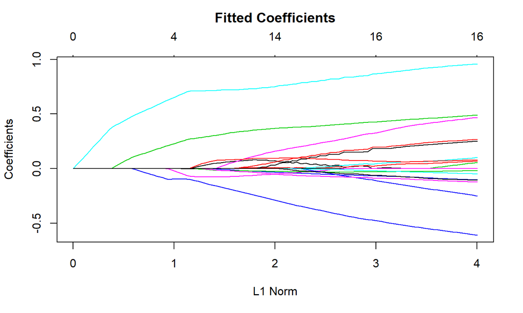

```r
library(glmnet);library(lars)
bcell <- glmnet(x = xmat, y = resp,family = "binomial") # binomial for binary response
plot(bcell)
title("Fitted Coefficients",line=2.5)
```

- We can tell which of the \(p = 12625\) features are important and classify \(n = 128\) individuals into two groups.

## Sensitivity and Specificity

- **Sensitivity** (also called the true positive rate) measures the proportion of actual positives which are correctly identified and is complementary to the false negative rate.
- **Specificity** (also called the true negative rate) measures the proportion of negatives which are correctly identified as such and is complementary to the false positive rate.

## Sensitivity

```r
pred.class <- predict(bcell,newx=xmat,s=NULL,type="class")
y.pred <- pred.class[,ncol(pred.class)]
y.obs <- resp
xtabs(~ y.obs +y.pred)
```

```
##      y.pred
## y.obs  B  T
##     B 95  0
##     T  0 33
```

- The classification table shows perfect specificity and sensitivity.
- Is this surprising?

## Heatmap

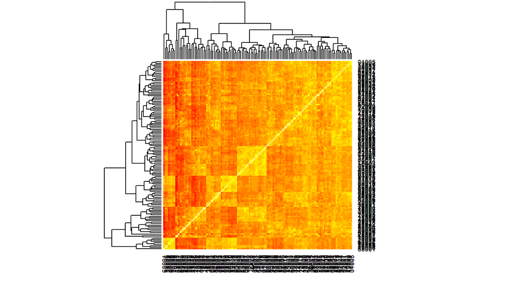

```r
heatmap(cor(t(xmat)))
```